# [Lecture Note] Repetition Structures

## Letting the User Control the Loop Iterations

- When the code was written, the programmer knew that the loop had to iterate over the values 1 through 10.
- Sometimes, the programmer needs to let the user control the number of times that a loop iterates.
- For example, what if you want the next program to be a bit more versatile by allowing the user to specify the maximum value displayed by the loop?

```python
# code_04_10_user_squares1.py
# This program uses a loop to display a
# table of numbers and their squares.

# Get the ending limit.
print('This program displays a list of numbers')
print('(starting at 1) and their squares.')
end = int(input('How high should I go? '))

# Print the table headings.
print()
print('Number\tSquare')
print('--------------')

# Print the numbers and their squares.
for number in range(1, end + 1):
    square = number**2
    print(number, '\t', square)
```

## Generating an Iterable Sequence that Ranges from Highest to Lowest

- In the examples you have seen so far, the range function was used to generate a sequence with numbers that go from lowest to highest.
- Alternatively, you can use the range function to generate sequences of numbers that go from highest to lowest.
- In this function call, the starting value is 10, the sequence’s ending limit is 0, and the step value is -1. This expression will produce the following sequence:

```python
range(10, 0, −1)

10, 9, 8, 7, 6, 5, 4, 3, 2, 1
```

- Here is an example of a for loop that prints the numbers 5 down to 1:

```python
for num in range(5, 0, −1):
  print(num)
```

# Calculating a Running Total

A running total is a sum of numbers that accumulates with each iteration of a loop. The variable used to keep the running total is called an accumulator.

- Many programming tasks require you to calculate the total of a series of numbers.
- For example, suppose you are writing a program that calculates a business’s total sales for a week.
  - The program would read the sales for each day as input and calculate the total of those numbers.
  - Programs that calculate the total of a series of numbers typically use two elements:
    - A loop that reads each number in the series.
    - A variable that accumulates the total of the numbers as they are read.

> The variable that is used to accumulate the total of the numbers is called an accumulator. It is often said that the loop keeps a running total because it accumulates the total as it reads each number in the series.

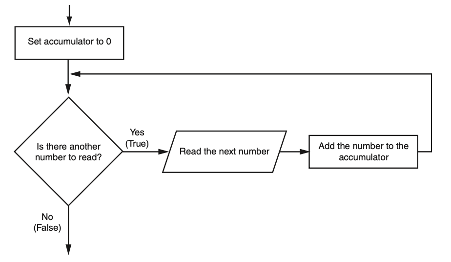

- When the loop finishes, the accumulator will contain the total of the numbers that were read by the loop.
- Notice the first step in the flowchart is to set the accumulator variable to 0.
- This is a critical step. Each time the loop reads a number, it adds it to the accumulator.
- If the accumulator starts with any value other than 0, it will not contain the correct total when the loop finishes.
- Let’s look at a program that calculates a running total. Program allows the user to enter five numbers, and displays the total of the numbers entered.

```python
# code_04_12_sum_numbers.py
# This program calculates the sum of a series
# of numbers entered by the user.

MAX = 5 # The maximum number

# Initialize an accumulator variable.
total = 0.0

# Explain what we are doing.
print('This program calculates the sum of')
print(MAX, 'numbers you will enter.')

# Get the numbers and accumulate them.
for counter in range(MAX):
    number = int(input('Enter a number: '))
    total = total + number

# Display the total of the numbers.
print('The total is', total)
```

```python
total = total + number
```

- After this statement executes, the value referenced by the number variable will be added to the value in the total variable.
- How this statement works.
  - First, the interpreter gets the value of the expression on the right side of the = operator, which is total + number.
  - Then, that value is assigned by the = operator to the total variable.
  - The effect of the statement is that the value of the number variable is added to the total variable.
  - When the loop finishes, the total variable will hold the sum of all the numbers that were added to it.

## The Augmented Assignment Operators

- Quite often, programs have assignment statements in which the variable that is on the left side of the ‘=’ operator also appears on the right side of the ‘=’ operator.

```python
x = x + 1
```

- On the right side of the assignment operator, 1 is added to x. The result is then assigned to x, replacing the value that x previously referenced.
- Effectively, this statement adds 1 to x.

```python
total = total + number
```

- This statement assigns the value of total + number to total.
- The effect of this statement is that number is added to the value of total.

```python
balance = balance − withdrawal
```

- This statement assigns the value of the expression “balance − withdrawal” to balance.
- The effect of this statement is that withdrawal is subtracted from balance.

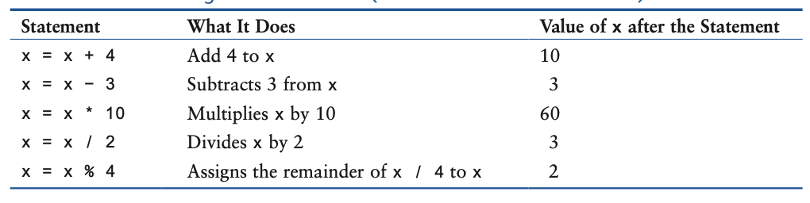

- These types of operations are common in programming.
- For convenience, Python offers a special set of operators designed specifically for these jobs.

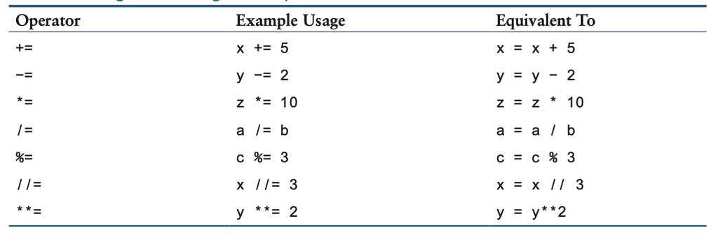

- As you can see, the augmented assignment operators do not require the programmer to type the variable name twice.

```python
total = total + number
```

could be rewritten as

```python
total += number
```

Similarly, the statement

```python
balance = balance − withdrawal
```

could be rewritten as

```python
balance −= withdrawal
```

# Sentinels

A sentinel is a special value that marks the end of a sequence of values.

- Consider this situation:
  - You are creating a program to process a series of values using a loop.
  - When designing your program, you don’t yet know how many values will be entered.
  - The number of values might even change each time the program runs.
- So, what is the best way to design this loop?
  - You could ask the user after each loop iteration if there’s another item, but if the sequence is long, asking repeatedly would be inconvenient.
  - Alternatively, you could ask the user to specify at the start how many values there are, but this would require extra effort if the user doesn’t already know or would have to count the items.

> A better and simpler solution is usually to use a “sentinel” value. A sentinel is a special value that signals the end of a series.
- Here’s how a sentinel works with an example:
  - Suppose a doctor wants a program to calculate the average weight of her patients.
  - The program repeatedly asks the user to enter each patient’s weight or enter 0 to show that there are no more weights.
  - The number 0 here is the “sentinel” value, signaling the end of the data input.
  - When the user inputs 0, the program understands that no more values will be entered, so it stops the loop and calculates and displays the average.

> A sentinel must be unique enough to not be confused with regular input. In this example, using “0” works well because a patient will never weigh 0 pounds.

# Input Validation Loops

Input validation is the process of inspecting data that has been input to a program, to make sure it is valid before it is used in a computation. Input validation is commonly done with a loop that iterates as long as an input variable references bad data.

- “garbage in, garbage out.”, sometimes abbreviated as GIGO
  - Refers to the fact that computers can not tell the difference between good data and bad data.
  - If a user provides bad data as input to a program, the program will process that bad data and,
  - As a result, will produce bad data as output.

```python
# code_04_14_gross_pay.py
# This program displays gross pay.
# Get the number of hours worked.
hours = int(input('Enter the hours worked this week: '))

# Get the hourly pay rate.
pay_rate = float(input('Enter the hourly pay rate: '))

# Calculate the gross pay.
gross_pay = hours * pay_rate

# Display the gross pay.
print('Gross pay: $', format(gross_pay, ',.2f'))
```

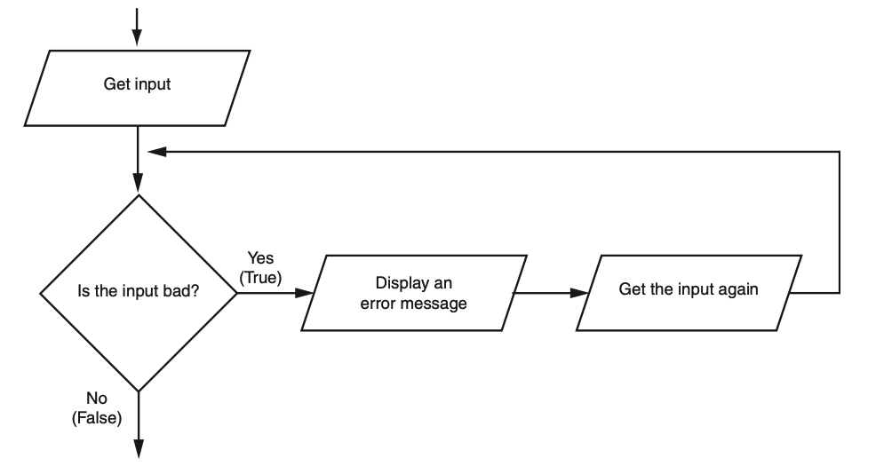

- Notice the flowchart reads input in two places:
  - First just before the loop, and then inside the loop.
  - The first input operation—just before the loop—is called a **priming read**, and its purpose is to get the first input value that will be tested by the validation loop.
- If that value is invalid, the loop will perform subsequent input operations.
- Suppose you are designing a program that reads a test score and you want to make sure the user does not enter a value less than 0.
- The following code shows how you can use an input validation loop to reject any input value that is less than 0.

```python
# Get a test score.
score = int(input('Enter a test score: '))
# Make sure it is not less than 0.
while score < 0:
  print('ERROR: The score cannot be negative.')
  score = int(input('Enter the correct score: '))
```

- The code first asks the user to enter a test score (known as the priming read).
- Then, a while loop checks if the score is valid.
  - Remember, a while loop always checks a condition before it runs.
- If the initial input is valid (score is not less than 0), the loop doesn’t run at all.
- If the initial input is invalid (score less than 0), the loop performs these actions:
  - Shows an error message.
  - Prompts the user to enter a correct test score.
  - Repeats these steps until the user enters valid input.

**Note**

An input validation loop is sometimes called an error trap or an error handler.

- This code rejects only negative test scores. What if you also want to reject any test scores that are greater than 100? You can modify the input validation loop so it uses a compound Boolean expression, as shown next.

```python
# Get a test score.
score = int(input('Enter a test score: '))
# Make sure it is not less than 0 or greater than 100.
while score < 0 or score > 100:
  print('ERROR: The score cannot be negative')
  print('or greater than 100.')
  score = int(input('Enter the correct score: '))
```

- The loop in this code determines whether score is less than 0 or greater than 100.
- If either is true, an error message is displayed and the user is prompted to enter a correct score.

# Nested Loops

A loop that is inside another loop is called a nested loop.

```python
It displays the seconds from 0 to 59:
for seconds in range(60):
  print(seconds)
```

- We can add a minutes variable and nest the loop above inside another loop that cycles through 60 minutes:

```python
for minutes in range(60):
  for seconds in range(60):
    print(minutes, ':', seconds)
```

- To make the simulated clock complete, another variable and loop can be added to count the hours:

```python
for hours in range(24):
  for minutes in range(60):
    for seconds in range(60):
      print(hours, ':', minutes, ':', seconds)

#This code’s output would be:
0 : 0 : 0
0 : 0 : 1
0 : 0 : 2

#(The program will count through each second of 24 hours.)

23 : 59 : 59
```

- The innermost loop will iterate 60 times for each iteration of the middle loop.
- The middle loop will iterate 60 times for each iteration of the outermost loop.
- When the outermost loop has iterated 24 times, the middle loop will have iterated 1,440 times and the innermost loop will have iterated 86,400 times!

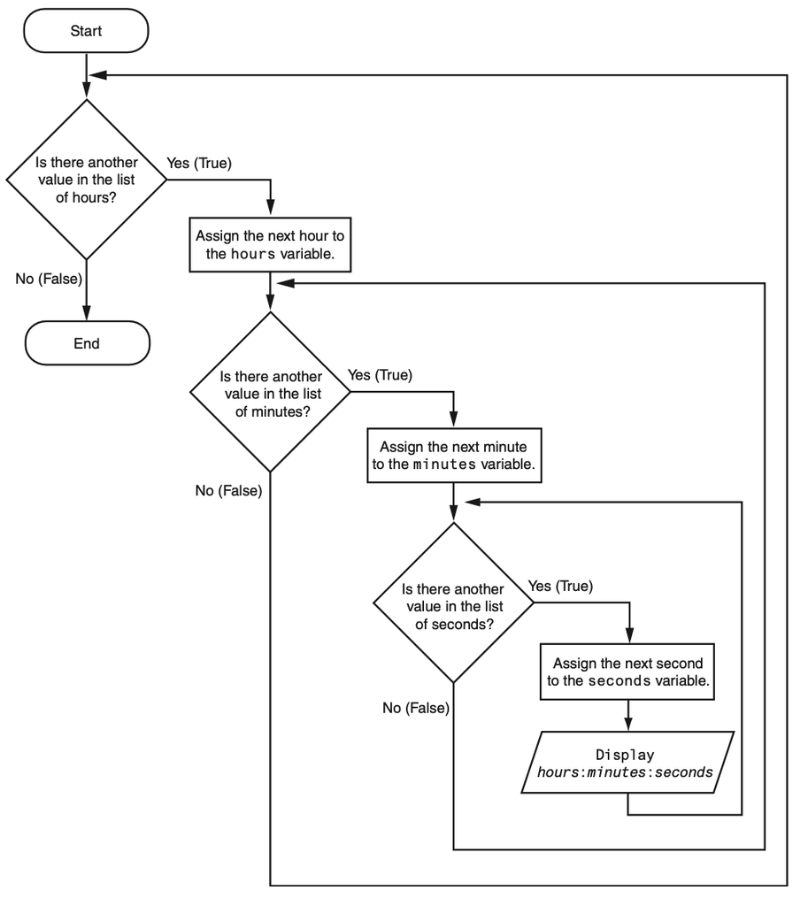

# Turtle Graphics: Using Loops to Draw Designs

You can use loops to draw graphics that range in complexity from simple shapes to elaborate designs.

- You can use loops with the turtle to draw both simple shapes and elaborate designs.
- For example, the following for loop iterates four times to draw a square that is 100 pixels wide:

```python
for x in range(4):
  turtle.forward(100)
  turtle.right(90)
```

- The following code shows another example. This for loop iterates eight times to draw the octagon

```python
for x in range(8):
  turtle.forward(100)
  turtle.right(45)
```

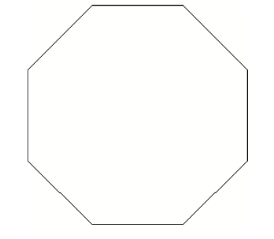

- You can create a lot of interesting designs with the turtle by repeatedly drawing a simple shape, with the turtle tilted at a slightly different angle each time it draws the shape.

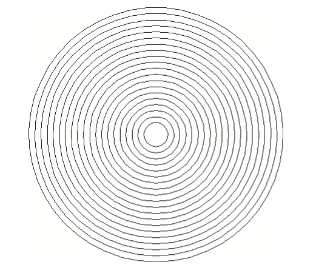

- For example, drawing 36 circles with a loop.
  - After each circle was drawn, the turtle was tilted left by 10 degrees.

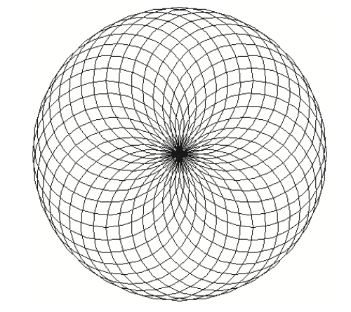

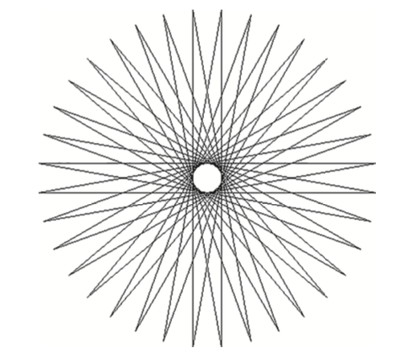

# House Keeping